# Customer Segmentation

Dataset comprises records for over 24,000 customers from a retail store, including bill amounts, age, and vintage information.

#### Objective:

To create customer segments for targeted marketing efforts.

#### Packages/Libraries required

```r
library(dplyr)
library(purrr)
library(ggplot2)
library(factoextra)
```

#### Data Description

| Column_Name | Column_description |
| --- | --- |
| Cust_ID | Customer ID for each customer |
| Age | Age of the Customer |
| BillAmt_Product | Totat amount of Product purchase in year 2023 |
| BillAmt_Service | Totat amount of Service purchase in year 2023 |
| BillAmt_Pre | Totat amount of Product purchase in previous year |
| Vintage | Number of years since the customer is in business with the company |

#### Import the data “Customer Segment” using read.csv function

```r
custsales=read.csv(file.choose())
head(custsales)
```

```
  Cust_ID Age BillAmt_Product BillAmt_Service BillAmt_Pre Vintage
1   82078  49        81128.27        48203.10    62975.45       5
2   57215  34        59480.20        17263.19    23633.58       5
3   66970  58        65363.07        30660.67    45888.87       6
4   77319  48        84073.28        47181.46    43186.04       7
5   29564  26        10541.03         3550.96    12753.15       1
6   40744  30        54889.43        17371.42    32344.42       3
```

[output not shown]

```r
dim(custsales)
```

```
[1] 24019     6
```

#### Omitting the rows with missing values

```r
custsales<-na.omit(custsales)
```

#### Subset data by deleting CustomerID for clustering

```r
custsales_cl<-subset(custsales,select=-Cust_ID)
head(custsales_cl)
```

```
  Age BillAmt_Product BillAmt_Service BillAmt_Pre Vintage
1  49        81128.27        48203.10    62975.45       5
2  34        59480.20        17263.19    23633.58       5
3  58        65363.07        30660.67    45888.87       6
4  48        84073.28        47181.46    43186.04       7
5  26        10541.03         3550.96    12753.15       1
6  30        54889.43        17371.42    32344.42       3
```

#### Standardise all variables using scale function

```r
custsales_cl<-scale(custsales_cl) %>% as.data.frame()
head(custsales_cl)
```

```
         Age BillAmt_Product BillAmt_Service  BillAmt_Pre    Vintage
1  0.7545411       1.1928128       1.8349670  1.654465212  0.5574361
2 -0.4604792       0.4661426      -0.1644493 -0.478878917  0.5574361
3  1.4835533       0.6636155       0.7013302  0.727931849  0.9703218
4  0.6735398       1.2916693       1.7689460  0.581368747  1.3832075
5 -1.1084900      -1.1766199      -1.0505687 -1.068878870 -1.0941067
6 -0.7844846       0.3120422      -0.1574552 -0.006526703 -0.2683353
```

#### Create plot for elbow method to decide optimum number of clusters

**Syntax**: library(factoextra)  
fviz_nbclust(custsales_cl, kmeans,method = “wss”)

**Note**: In case you are using R on a computer that has low processing (CPU) power or memory (RAM), you might encounter problems when running the above command with large datasets. Hence, as an alternative below function is used:

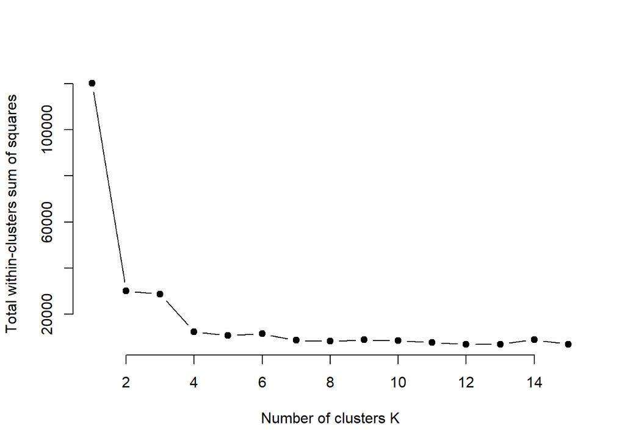

```r
wss <- function(k) {
  kmeans(custsales_cl, k,iter.max = 1000)$tot.withinss
}

k.values <- 1:15

wss_values <- map_dbl(k.values, wss)

plot(k.values, wss_values,
     type="b", pch = 19, frame = FALSE,
     xlab="Number of clusters K",
     ylab="Total within-clusters sum of squares")
```

- The **`map_dbl()`** function from the **`purrr`** package is used to apply the **`wss`** function to each value of **`k.values`***`(i.e. 1 to 15)`*. It calculates the total within-cluster sum of squares for each value of **`k`** and stores the results in the vector **`wss_values`**.
- iter.max = 1000 specifies the maximum number of iterations allowed in the K-means algorithm.

**Comment**: Using elbow method, K=4 clusters are finalized

#### Running kmeans

set.seed() is used to ensure reproducibility of the results given by kmeans function

```r
set.seed(123)
CL<-kmeans(custsales_cl,4)
```

#### Cluster size(No. of customers in each cluster)

```r
CL$size
```

```
[1] 4000 8051 7895 4073
```

#### Add cluster membership to the data

```r
custsales$segment<- CL$cluster
head(custsales)
```

```
  Cust_ID Age BillAmt_Product BillAmt_Service BillAmt_Pre Vintage segment
1   82078  49        81128.27        48203.10    62975.45       5       3
2   57215  34        59480.20        17263.19    23633.58       5       1
3   66970  58        65363.07        30660.67    45888.87       6       3
4   77319  48        84073.28        47181.46    43186.04       7       3
5   29564  26        10541.03         3550.96    12753.15       1       2
6   40744  30        54889.43        17371.42    32344.42       3       4
```

#### Calculate mean of each variable clusterwise and round off values to two decimal places

```r
allmean <- aggregate(cbind(Age ,BillAmt_Product ,BillAmt_Service,BillAmt_Pre,Vintage)~segment,data=custsales,FUN=mean)
allmean=allmean %>% map(round,2) %>% as.data.frame()
allmean
```

```
  segment   Age BillAmt_Product BillAmt_Service BillAmt_Pre Vintage
1       1 37.51        42544.33        16038.35    30257.02    4.50
2       2 26.99        12576.65         3761.71    12575.10    1.00
3       3 54.97        82354.48        40049.61    55064.95    6.50
4       4 37.28        42594.78        15992.31    30140.83    2.52
```

**Comment**:

- Segment number 3 is made up of platinum customers who have greater bill amounts; also, customers in this segment are older and have been conducting business with the company for a longer period of time.
- The customer in segment 2 are young and have been in business with company for just one one year

#### Summarising each variables( average value) within each cluster

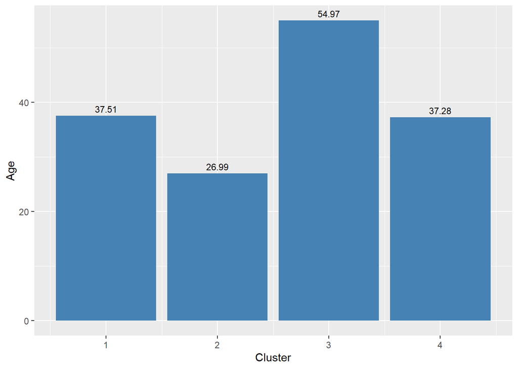

```r
ggplot(allmean, aes(x = segment, y = Age)) +
           geom_bar(stat = "identity", fill = "steelblue") +
             geom_text(aes(label = Age), vjust = -0.5, color = "black", size = 3) +
           labs(x = "Cluster", y = "Age")
```

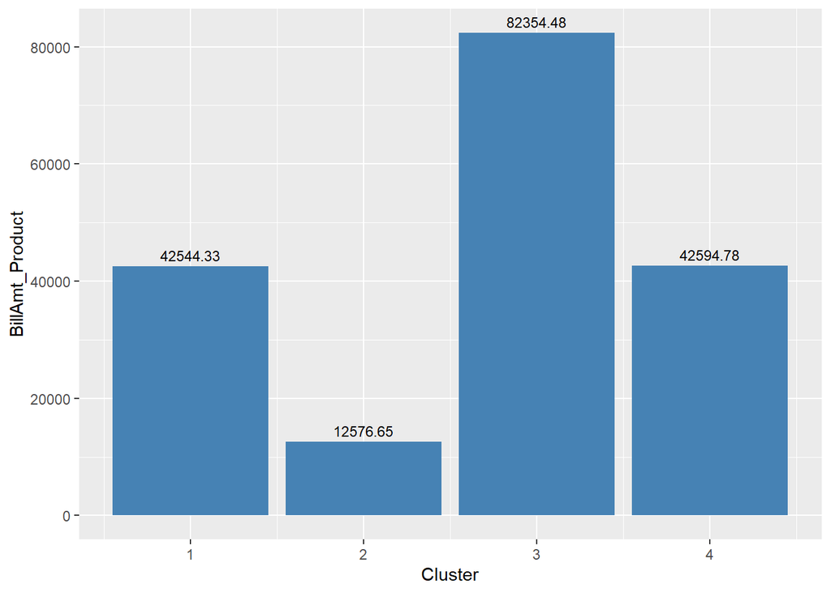

```r
ggplot(allmean, aes(x = segment, y = BillAmt_Product)) +
           geom_bar(stat = "identity", fill = "steelblue") +
           geom_text(aes(label = BillAmt_Product), vjust = -0.5, color = "black", size = 3) +
           labs(x = "Cluster", y = "BillAmt_Product")
```

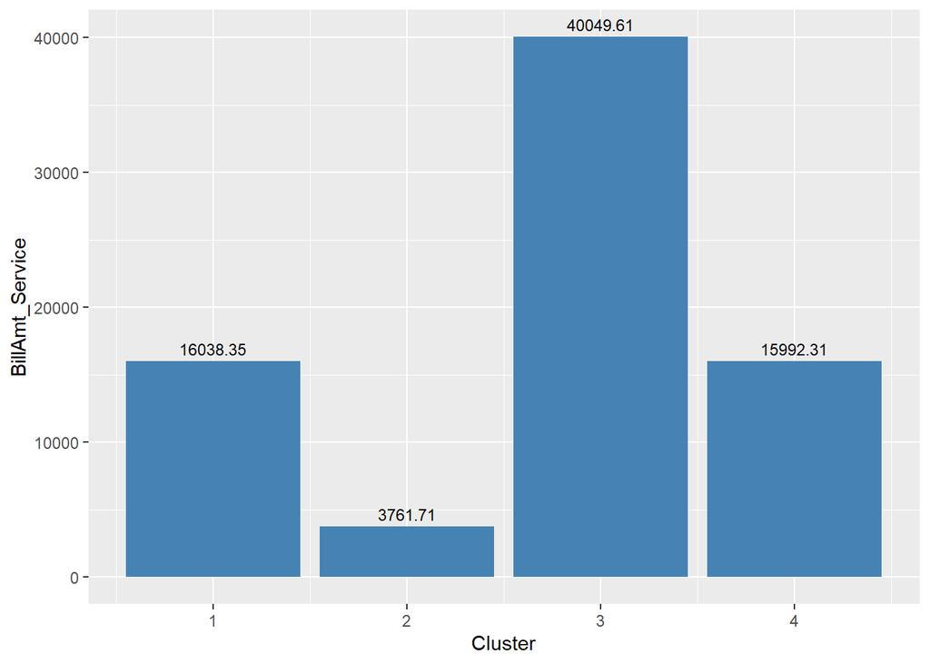

```r
ggplot(allmean, aes(x = segment, y = BillAmt_Service)) +
           geom_bar(stat = "identity", fill = "steelblue") +
           geom_text(aes(label = BillAmt_Service), vjust = -0.5, color = "black", size = 3) +
           labs(x = "Cluster", y = "BillAmt_Service")
```

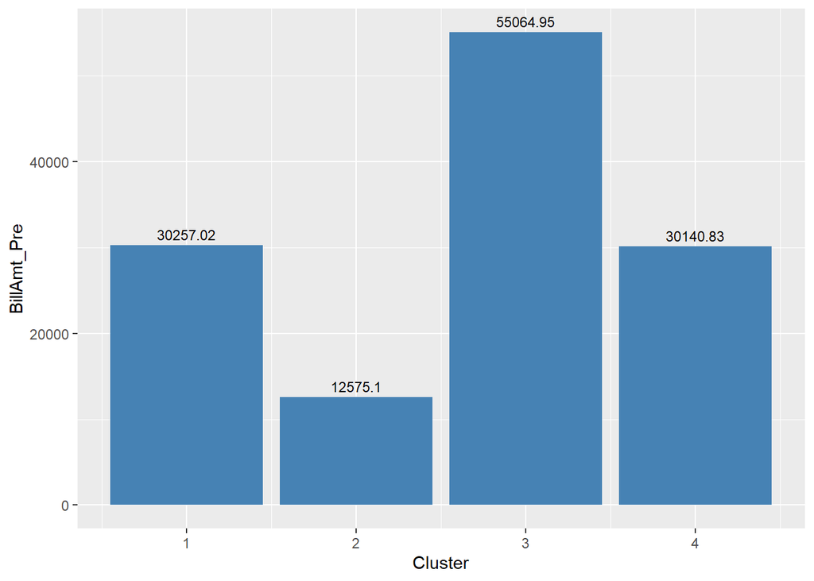

```r
ggplot(allmean, aes(x = segment, y = BillAmt_Pre)) +
           geom_bar(stat = "identity", fill = "steelblue") +
           geom_text(aes(label = BillAmt_Pre), vjust = -0.5, color = "black", size = 3) +
           labs(x = "Cluster", y = "BillAmt_Pre")
```

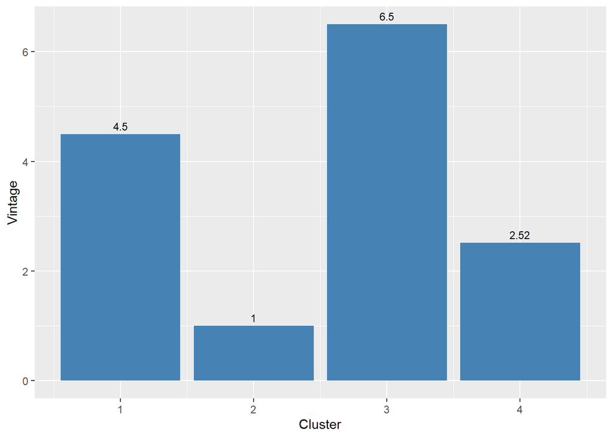

```r
ggplot(allmean, aes(x = segment, y = Vintage)) +
           geom_bar(stat = "identity", fill = "steelblue") +
           geom_text(aes(label = Vintage), vjust = -0.5, color = "black", size = 3) +
           labs(x = "Cluster", y = "Vintage")
```